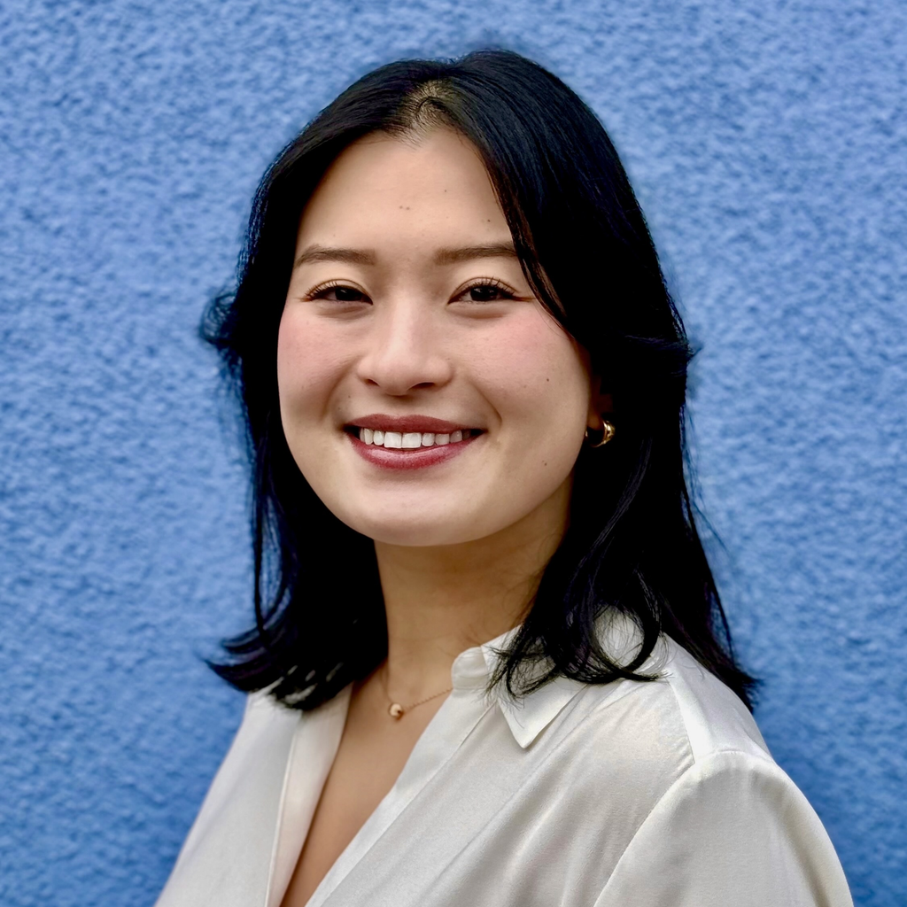

# Kaitlyn Lee

## Bio

Kaitlyn Lee is a third year PhD student in Biostatistics at the UC Berkeley mentored by [Professor Alejandro Schuler](https://ctml.berkeley.edu/people/alejandro-schuler-phd). Her research interests are broadly in causal inference, machine learning, and methods research. She is interested in developing methods to answer real-world questions about health and social policy in a statistically rigorous manner. Her current work focuses on efficient estimation of causal quantities using machine learning algorithms.

## Education

**UC Berkeley** | Berkeley, CA

PhD in Biostatistics | August 2022 - May 2027 (expected)

MA in Biostatistics | August 2022 - August 2024

**Harvard College** | Cambridge, MA

AB in Physics with Statistics Secondary | August 2016 - May 2020

## Awards and Fellowships

NSF GRFP Fellow | 2024 - 2027

Biostatistics DEIB Fellow | 2024

Stern Health Fellow | 2022 - 2027

UC Berkeley Berkeley Fellowship | 2022 - 2024

UC Berkeley Chancellor’s Fellowship | 2022 - 2023

## Experience

[**Center for Targeted Machine Learning**](https://ctml.berkeley.edu)**, UC Berkeley** | Graduate Student Researcher | Fall 2023 - Present

[**Huybers Lab**](https://phuybers.sites.fas.harvard.edu)**, Harvard University** | Research Assistant | May 2020 - December 2020

## Publications and Conference Presentations

- **Lee, K. J.**, Schuler, A. (2025). RieszBoost: Gradient Boosting for Riesz Regression. [arXiv:2501.04871](https://arxiv.org/abs/2501.04871).
- **Lee, K. J.**, Hubbard, A., Schuler, A. (2024). Bridging Binarization: Causal Inference with Dichotomized Continuous Exposures. [arXiv:2405.07109](https://arxiv.org/abs/2405.07109). (In Review)
- **Lee, K. J.**, Hubbard, A., Schuler, A. (2024, May 15). *Bridging Binarization: Causal Inference with Dichotomized Continuous Treatments* [Poster Session]. American Causal Inference Conference, Seattle, WA.
- **Lee, K. J.**, Hubbard, A., Schuler, A. (2024, June 20). *Bridging Binarization: Causal Inference with Dichotomized Continuous Treatments* [Poster Session]. Society of Epidemiological Research Conference, Austin, TX.
- Gordon, E. R., Trager, M. H., Kwinta, B. D., Stonesifer, C. J., **Lee, K. J.**, Adeuyan, O., … Geskin, L. J. (2024). Maintenance therapy for CTCL: importance for prevention of disease progression. *Leukemia & Lymphoma*, 1–8. https://doi.org/10.1080/10428194.2024.2376164.